# Pediatric Hepatitis C Patient Outcomes in a Tertiary Academic Medical Center Utilizing an Integrated Specialty Pharmacy Model: HSSP Study

# 1 Study Details

## 1.1 Background

FDA approvals of hepatitis C medications (Harvoni, Epclusa, and Mavyret) for the pediatric population <18 years of age began in April of 2017. HSSP worked with the pediatric hepatology clinic to assist with starting treatment for these patients. HSSP pharmacists worked with patients on swallowing tablets and pellets, the insurance approval process, education of medication, on treatment monitoring, and ensuring labs completed for sustained virologic response (SVR); otherwise known as cure.

## 1.2 Methods

Descriptive report of sustained virologic response (SVR) rates, adherence rates, and side effects among a pediatric population with HCV.

### 1.2.1 Inclusion Criteria

- Patients <18 years
- Patients seen by a pediatric hepatologist at the Pediatric Hepatology Clinic at the Monroe Carrell Jr. Children’s Hospital at Vanderbilt
- Clinic visits between January 2017 and September 2022.
- Exclusion: Patients not initiating DAA treatment

## 1.3 Outcomes

**Primary outcome:** Determine SVR rates in patients that successfully started treatment

**Secondary outcomes:**

- Frequency and response to DAA administration challenges (e.g., alternative administration modalities or frequencies)
- Patient Reported adherence
- Number and type of patient-reported side effects
- Number and type of drug/drug interactions
- Number and type of pharmacist interventions performed

# 2 Analysis

## 2.1 Demographics

### 2.1.1 All treatment initiated patients

```r
tab <- summaryM(age + sex + Race + height + weight + bmi +InsuranceType + referred_vsp + medication_initiation ~1,
                data=dat[dat$medication_initiation == "Initiated",],continuous=5, na.include=T)
Hmisc::html(tab,
      caption="Patient Characteristics",long=T,exclude1=F)
```

| Patient Characteristics. | Patient Characteristics. *N=64* |
| --- | --- |
| Age | 5.00 6.00 9.25 |
| Gender |  |
| Female | 0.56 (36) |
| Male | 0.44 (28) |
| Race |  |
| Hispanic/Latino | 0.02 ( 1) |
| Black or African American | 0.00 ( 0) |
| White | 0.73 (47) |
| Unknown / Not Reported | 0.22 (14) |
| Other | 0.02 ( 1) |
| Arabic | 0.02 ( 1) |
| Height (cm) | 109.75 120.00 141.25 |
| Weight (kilograms) | 19.9250 26.6500 38.8625 |
| BMI | 16.275 17.950 21.625 |
| InsuranceType |  |
| Medicaid | 0.83 (53) |
| Commercial | 0.17 (11) |
| None | 0.00 ( 0) |
| Was patient referred to HSSP? |  |
| Yes | 1 (64) |
| No | 0 ( 0) |
| Medication Initiation |  |
| Initiated | 1 (64) |

*a* *b* *c* represent the lower quartile *a*, the median *b*, and the upper quartile *c* for continuous variables. Numbers after proportions are frequencies.

### 2.1.2 Intiated patients grouped by FDA age groups

```r
tab <- summaryM(age + sex + Race + height + weight + bmi +InsuranceType + genotype+
                  referred_vsp + medication_initiation + Regimen + fibrosis_score  + viral_load_b +dosage_form + daa_lot +
                  treatment_naive  + ast_b + alt_b  ~ age_group,
                data=dat[!is.na(dat$daa_b_start_date),],continuous=5, na.include=T, overall=T)
Hmisc::html(tab,
      caption="Treatment Initiated Patient Characteristics",long=T,exclude1=F, digits=3)
```

| Treatment Initiated Patient Characteristics. | Treatment Initiated Patient Characteristics. 0-5 years *N=20* | Treatment Initiated Patient Characteristics. 6-11 years *N=32* | Treatment Initiated Patient Characteristics. 12-17 years *N=12* | Treatment Initiated Patient Characteristics. Combined *N=64* |
| --- | --- | --- | --- | --- |
| Age | 4.00 5.00 5.00 | 6.00 7.00 8.25 | 13.75 15.00 15.25 | 5.00 6.00 9.25 |
| Gender |  |  |  |  |
| Female | 0.40 ( 8) | 0.59 (19) | 0.75 ( 9) | 0.56 (36) |
| Male | 0.60 (12) | 0.41 (13) | 0.25 ( 3) | 0.44 (28) |
| Race |  |  |  |  |
| Hispanic/Latino | 0.00 ( 0) | 0.00 ( 0) | 0.08 ( 1) | 0.02 ( 1) |
| Black or African American | 0.00 ( 0) | 0.00 ( 0) | 0.00 ( 0) | 0.00 ( 0) |
| White | 0.70 (14) | 0.78 (25) | 0.67 ( 8) | 0.73 (47) |
| Unknown / Not Reported | 0.30 ( 6) | 0.22 ( 7) | 0.08 ( 1) | 0.22 (14) |
| Other | 0.00 ( 0) | 0.00 ( 0) | 0.08 ( 1) | 0.02 ( 1) |
| Arabic | 0.00 ( 0) | 0.00 ( 0) | 0.08 ( 1) | 0.02 ( 1) |
| Height (cm) | 101 105 110 | 118 124 132 | 151 157 163 | 110 120 141 |
| Weight (kilograms) | 17.1 18.8 20.8 | 24.8 27.3 33.3 | 43.5 55.7 62.4 | 19.9 26.6 38.9 |
| BMI | 15.4 17.0 18.3 | 16.5 17.6 20.5 | 19.2 21.8 24.8 | 16.3 18.0 21.6 |
| InsuranceType |  |  |  |  |
| Medicaid | 0.85 (17) | 0.81 (26) | 0.83 (10) | 0.83 (53) |
| Commercial | 0.15 ( 3) | 0.19 ( 6) | 0.17 ( 2) | 0.17 (11) |
| None | 0.00 ( 0) | 0.00 ( 0) | 0.00 ( 0) | 0.00 ( 0) |
| Genotype |  |  |  |  |
| Genotype 1 | 0.85 (17) | 0.69 (22) | 0.83 (10) | 0.77 (49) |
| Genotype 2 | 0.05 ( 1) | 0.06 ( 2) | 0.00 ( 0) | 0.05 ( 3) |
| Genotype 3 | 0.10 ( 2) | 0.25 ( 8) | 0.08 ( 1) | 0.17 (11) |
| Genotype 4 | 0.00 ( 0) | 0.00 ( 0) | 0.08 ( 1) | 0.02 ( 1) |
| Was patient referred to HSSP? |  |  |  |  |
| Yes | 1 (20) | 1 (32) | 1 (12) | 1 (64) |
| No | 0 ( 0) | 0 ( 0) | 0 ( 0) | 0 ( 0) |
| Medication Initiation |  |  |  |  |
| Initiated | 1 (20) | 1 (32) | 1 (12) | 1 (64) |
| Regimen |  |  |  |  |
| Epclusa 200/50mg Pellets x 12 weeks | 0.05 ( 1) | 0.00 ( 0) | 0.00 ( 0) | 0.02 ( 1) |
| Epclusa 200/50mg Tablets x 12 weeks | 0.15 ( 3) | 0.22 ( 7) | 0.00 ( 0) | 0.16 (10) |
| Epclusa 400/100mg Pellets x 12 weeks | 0.00 ( 0) | 0.06 ( 2) | 0.00 ( 0) | 0.03 ( 2) |
| Epclusa 400/100mg Tablets x 12 weeks | 0.00 ( 0) | 0.12 ( 4) | 0.00 ( 0) | 0.06 ( 4) |
| Harvoni 33.75/150mg Pellets x 12 weeks | 0.15 ( 3) | 0.00 ( 0) | 0.00 ( 0) | 0.05 ( 3) |
| Harvoni 45/200mg Pellets x 12 weeks | 0.10 ( 2) | 0.03 ( 1) | 0.00 ( 0) | 0.05 ( 3) |
| Harvoni 45/200mg Tablets x 12 weeks | 0.55 (11) | 0.47 (15) | 0.00 ( 0) | 0.41 (26) |
| Harvoni 90/400mg Tablets x 12 weeks | 0.00 ( 0) | 0.09 ( 3) | 0.67 ( 8) | 0.17 (11) |
| Mavyret 300/120mg Tablets x 8 weeks | 0.00 ( 0) | 0.00 ( 0) | 0.33 ( 4) | 0.06 ( 4) |
| Fibrosis Score |  |  |  |  |
| F0 | 0.10 ( 2) | 0.06 ( 2) | 0.25 ( 3) | 0.11 ( 7) |
| F1 | 0.00 ( 0) | 0.03 ( 1) | 0.17 ( 2) | 0.05 ( 3) |
| F2 | 0.00 ( 0) | 0.00 ( 0) | 0.00 ( 0) | 0.00 ( 0) |
| F3 | 0.00 ( 0) | 0.00 ( 0) | 0.00 ( 0) | 0.00 ( 0) |
| F4 | 0.00 ( 0) | 0.03 ( 1) | 0.00 ( 0) | 0.02 ( 1) |
| F0-1 | 0.00 ( 0) | 0.00 ( 0) | 0.00 ( 0) | 0.00 ( 0) |
| F1-2 | 0.00 ( 0) | 0.00 ( 0) | 0.00 ( 0) | 0.00 ( 0) |
| F2-3 | 0.00 ( 0) | 0.03 ( 1) | 0.00 ( 0) | 0.02 ( 1) |
| F3-4 | 0.00 ( 0) | 0.00 ( 0) | 0.00 ( 0) | 0.00 ( 0) |
| no score available and no cirrhosis | 0.90 (18) | 0.84 (27) | 0.58 ( 7) | 0.81 (52) |
| no score available and unknown cirrhosis status | 0.00 ( 0) | 0.00 ( 0) | 0.00 ( 0) | 0.00 ( 0) |
| Baseline Viral Load (IU/mL) | 295219 852079 3668653 | 423922 1396356 2928785 | 349904 554147 2215088 | 392422 1077115 3240835 |
| Tablets or Pellets |  |  |  |  |
| Tablets | 0.70 (14) | 0.91 (29) | 1.00 (12) | 0.86 (55) |
| Pellets | 0.30 ( 6) | 0.09 ( 3) | 0.00 ( 0) | 0.14 ( 9) |
| Length of DAA Regimen |  |  |  |  |
| 8 weeks | 0.00 ( 0) | 0.00 ( 0) | 0.33 ( 4) | 0.06 ( 4) |
| 12 weeks | 1.00 (20) | 1.00 (32) | 0.67 ( 8) | 0.94 (60) |
| 16 weeks | 0.00 ( 0) | 0.00 ( 0) | 0.00 ( 0) | 0.00 ( 0) |
| 24 weeks | 0.00 ( 0) | 0.00 ( 0) | 0.00 ( 0) | 0.00 ( 0) |
| Other | 0.00 ( 0) | 0.00 ( 0) | 0.00 ( 0) | 0.00 ( 0) |
| Treatment naïve |  |  |  |  |
| Yes | 1 (20) | 1 (32) | 1 (12) | 1 (64) |
| No | 0 ( 0) | 0 ( 0) | 0 ( 0) | 0 ( 0) |
| AST (U/L) | 44.8 56.5 72.0 | 33.8 42.0 54.2 | 30.2 37.0 50.5 | 34.8 45.5 62.0 |
| ALT (U/L) | 41.0 64.0 88.2 | 33.8 45.5 65.0 | 29.8 48.0 70.0 | 34.0 49.5 79.0 |

*a* *b* *c* represent the lower quartile *a*, the median *b*, and the upper quartile *c* for continuous variables. Numbers after proportions are frequencies.

## 2.2 SVR rates, adherence, side effects, and interventions

- SVR rate, medication interactions, side effects, and adherence rates were only examined in patients that initiated medication

### 2.2.1 SVR Rates

```r
tab <- summaryM(svr_achieved~age_group,
                data=dat[!is.na(dat$daa_b_start_date),],continuous=5, na.include=T, overall=T)
Hmisc::html(tab,
      caption="SVR Rates",long=T,exclude1=F)
```

| SVR Rates. | SVR Rates. 0-5 years *N=20* | SVR Rates. 6-11 years *N=32* | SVR Rates. 12-17 years *N=12* | SVR Rates. Combined *N=64* |
| --- | --- | --- | --- | --- |
| SVR achieved |  |  |  |  |
| Yes | 0.90 (18) | 0.97 (31) | 0.83 (10) | 0.92 (59) |
| No | 0.05 ( 1) | 0.00 ( 0) | 0.00 ( 0) | 0.02 ( 1) |
| LTFU | 0.05 ( 1) | 0.03 ( 1) | 0.08 ( 1) | 0.05 ( 3) |
| Reinfection | 0.00 ( 0) | 0.00 ( 0) | 0.08 ( 1) | 0.02 ( 1) |
| Pending Appointment | 0.00 ( 0) | 0.00 ( 0) | 0.00 ( 0) | 0.00 ( 0) |

Numbers after proportions are frequencies.

### 2.2.2 Adherence rates

```r
tab <- summaryM(daa1_yn_missed + daa1_missed_doses + daa1_reason_missed + pharm_missed_interventions ~1,
                data=dat[!is.na(dat$daa_b_start_date),],continuous=5, na.include=T)
Hmisc::html(tab,
      caption="Adherence",long=T,exclude1=F)
```

| Adherence. | Adherence. N | Adherence. *N=64* |
| --- | --- | --- |
| Were doses missed? | 64 |  |
| No |  | 0.69 (44) |
| Yes |  | 0.31 (20) |
| Number of Doses Missed | 20 | 1 2 6 |
| Why were doses missed? | 64 |  |
| swallowing issue |  | 0.06 ( 4) |
| alternate caregiver |  | 0.02 ( 1) |
| forgetfulness |  | 0.03 ( 2) |
| vomiting |  | 0.09 ( 6) |
| insurance lapse |  | 0.02 ( 1) |
| unknown |  | 0.09 ( 6) |
| NA |  | 0.69 (44) |
| Number of missed doses interventions | 64 |  |
| 0 |  | 0.80 (51) |
| 1 |  | 0.14 ( 9) |
| 2 |  | 0.06 ( 4) |

*a* *b* *c* represent the lower quartile *a*, the median *b*, and the upper quartile *c* for continuous variables. *N* is the number of non-missing values. Numbers after proportions are frequencies.

### 2.2.3 Side Effects

#### 2.2.3.1 Side effects overall

The reported side effects were not mutually exclusive. See the next tab for a visualization and count of the most common intersections.

```r
tab <- summaryM(TotalSideEffects + pharm_ade_interventions +
                  dda1_side_effects___0 + dda1_side_effects___1 + dda1_side_effects___2 + dda1_side_effects___3 +
                  dda1_side_effects___4 + dda1_side_effects___5 + dda1_side_effects___6 +dda1_side_effects___7 +
                  dda1_side_effects___8+ dda1_side_effects___9 +dda1_side_effects___10 + dda1_side_effects___11 +
                  dda1_side_effects___12 + dda1_side_effects___13 + dda1_side_effects___14 + dda1_side_effects___15 +
                  dda1_side_effects___16 + dda1_side_effects___17 + dda1_side_effects___18 + dda1_side_effects___19~1,
                data=dat[!is.na(dat$daa_b_start_date),],continuous=5, na.include=T)
Hmisc::html(tab,
      caption="Side Effects",long=T,exclude1=F)
```

| Side Effects. | Side Effects. *N=64* |
| --- | --- |
| Total side effects | 0 1 1 |
| Number of adverse drug interventions | 0 0 1 |
| Patient-reported Side Effects (choice=None) |  |
| None | 0.47 (30) |
| NA | 0.53 (34) |
| Patient-reported Side Effects (choice=Headache) |  |
| Headache | 0.2 (13) |
| NA | 0.8 (51) |
| Patient-reported Side Effects (choice=Fatigue) |  |
| Fatigue | 0.2 (13) |
| NA | 0.8 (51) |
| Patient-reported Side Effects (choice=Nausea) |  |
| Nausea | 0.14 ( 9) |
| NA | 0.86 (55) |
| Patient-reported Side Effects (choice=Vomiting) |  |
| Vomiting | 0.11 ( 7) |
| NA | 0.89 (57) |
| Patient-reported Side Effects (choice=Diarrhea) |  |
| NA | 1 (64) |
| Patient-reported Side Effects (choice=Insomnia/Nightmares/Sleep Disturbance) |  |
| Insomnia/Nightmares/Sleep Disturbance | 0.08 ( 5) |
| NA | 0.92 (59) |
| Patient-reported Side Effects (choice=Anemia) |  |
| NA | 1 (64) |
| Patient-reported Side Effects (choice=Joint Pain) |  |
| Joint Pain | 0.02 ( 1) |
| NA | 0.98 (63) |
| Patient-reported Side Effects (choice=Skin Rash) |  |
| NA | 1 (64) |
| Patient-reported Side Effects (choice=Other) |  |
| NA | 1 (64) |
| Patient-reported Side Effects (choice=Behavioral Changes) |  |
| Behavioral Changes | 0.06 ( 4) |
| NA | 0.94 (60) |
| Patient-reported Side Effects (choice=Appetite Changes) |  |
| Appetite Changes | 0.03 ( 2) |
| NA | 0.97 (62) |
| Patient-reported Side Effects (choice=Constipation) |  |
| Constipation | 0.02 ( 1) |
| NA | 0.98 (63) |
| Patient-reported Side Effects (choice=Abdominal Pain/Cramps) |  |
| Abdominal Pain/Cramps | 0.03 ( 2) |
| NA | 0.97 (62) |
| Patient-reported Side Effects (choice=Itching) |  |
| Itching | 0.02 ( 1) |
| NA | 0.98 (63) |
| Patient-reported Side Effects (choice=Tinnitus) |  |
| Tinnitus | 0.02 ( 1) |
| NA | 0.98 (63) |
| Patient-reported Side Effects (choice=Increased Bleeding or Bruising) |  |
| Increased Bleeding or Bruising | 0.03 ( 2) |
| NA | 0.97 (62) |
| Patient-reported Side Effects (choice=HSV outbreak) |  |
| HSV outbreak | 0.02 ( 1) |
| NA | 0.98 (63) |
| Patient-reported Side Effects (choice=Dyspepsia) |  |
| Dyspepsia | 0.03 ( 2) |
| NA | 0.97 (62) |

*a* *b* *c* represent the lower quartile *a*, the median *b*, and the upper quartile *c* for continuous variables. Numbers after proportions are frequencies.

#### 2.2.3.2 Side effects intersection

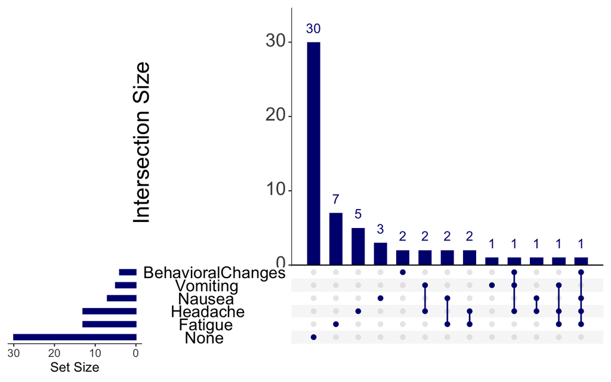

```r
ls <- list(
  None = which(!is.na(se$None)),
  Headache = which(!is.na(se$Headache)),
  Fatigue = which(!is.na(se$Fatigue)),
  Nausea = which(!is.na(se$Nausea)),
  Vomiting = which(!is.na(se$Vomiting)),
  Insomnia = which(!is.na(se$Insomnia)),
  JointPain = which(!is.na(se$`Joint Pain`)),
  SleepDisturbance = which(!is.na(se$`Insomnia/Nightmares/Sleep Disturbance`)),
  BehavioralChanges = which(!is.na(se$`Behavioral Changes`)),
  AppetiteChanges = which(!is.na(se$`Appetite Changes`)),
  Constipation = which(!is.na(se$Constipation)),
  AbdominalPain = which(!is.na(se$`Abdominal Pain/Cramps`)),
  Itching = which(!is.na(se$Itching)),
  Tinnitus = which(!is.na(se$Tinnitus)),
  BleedingBruising = which(!is.na(se$`Increased Bleeding or Bruising`)),
  HSVOutbreak = which(!is.na(se$`HSV outbreak`)),
  Dyspepsia = which(!is.na(se$Dyspepsia)),
  Other = which(!is.na(se$Other))
)
q2a <- upset(fromList(ls), nsets=6, order.by = "freq",
      text.scale = c(2.5, 2.5, 1.5, 1.5, 2.2, 2),
      main.bar.color="#000080", matrix.color="#000080",
      sets.bar.color="navyblue")
q2a
```

### 2.2.4 Side Effect Management

- Side effect management was free text. A key was used to categorize the variable.
- Multiple side effect managements occasionally occurred simultaneously, the total count is displayed below

```r
tmp1 <- stringr::str_split(dat$side_effect_mgmt_cat, ";")
names(tmp1) <- dat$study_id
res <- data.frame(matrix(NA, nrow=Reduce(`+`, lapply(tmp1, length)),ncol=2))
colnames(res) <- c("study_id", "side_effect_management")
counter <- 1
for(i in 1:length(tmp1)){
  id <- names(tmp1)[i]
  df <- as.data.frame(tmp1[i])
  df[grep("Other", df[,1]),1] <- "Other"
  res[i, "study_id"] <- id

  extra <- nrow(df) - 1
  res[counter:(counter+extra), c("study_id")] <- id
  res[counter:(counter+extra), c("side_effect_management")] <- df[,1]
  counter <- counter + extra + 1
}
res$side_effect_management <- stringr::str_trim(res$side_effect_management, "both")

#### Add total to bottom of table
table(res$side_effect_management[res$side_effect_management != "No side effect management"]) %>%
  as.data.frame() %>%
  dplyr::rename(side_effect_management = Var1, Frequency =Freq) %>%
  arrange(desc(Frequency)) %>%
  kable(caption="Total side effect managements") %>%
  kable_classic_2()
```

Table 2.1: Total side effect managements

| side_effect_management | Frequency |
| --- | --- |
| active listening/counseling | 20 |
| OTC supportive medication | 12 |
| RX supportive medication | 3 |
| dose administration counseling | 2 |
| Referred to PCP | 2 |
| Consulted non-HCV provider | 1 |
| Ordered labs | 1 |

### 2.2.5 Drug interactions

- Drug interaction management was free text and was categorized using a key
- One patient had two drug interactions. These are indicated with a semicolon

```r
#### Add table for total count of  drug_int_mgmt_cat

tab <- summaryM(drug_interaction_screen + pharm_di_interventions +drug_int_mgmt_cat ~1,
                data=dat[!is.na(dat$daa_b_start_date),],continuous=5, na.include=T)
Hmisc::html(tab,
      caption="Drug Interactions and Interventions",long=T,exclude1=F)
```

| Drug Interactions and Interventions. | Drug Interactions and Interventions. *N=64* |
| --- | --- |
| Do drug interactions exist? |  |
| No | 0.83 (53) |
| Yes | 0.17 (11) |
| Number of drug interaction management interventions |  |
| 0 | 0.83 (53) |
| 1 | 0.16 (10) |
| 2 | 0.02 ( 1) |
| Drug interaction management categorized |  |
| Dose of non-HCV medication adjusted; Timing of non-HCV medication administration adjusted | 0.02 ( 1) |
| Hold non-HCV medication | 0.09 ( 6) |
| No drug interaction management | 0.83 (53) |
| Timing of non-HCV medication administration adjusted | 0.06 ( 4) |

Numbers after proportions are frequencies.

### 2.2.6 Treatment Information

```r
pdat <-dat[dat$start == "Yes" & !is.na(dat$start),]
tab <- summaryM(Regimen  + genotype + daa_lot + liver_fibrosis_available +
                  fibrosis_score  + viral_load_b +
                  treatment_naive  + ast_b + alt_b~1,
                data=pdat,continuous=5, na.include=T)
Hmisc::html(tab,
      caption="Baseline Treatment Information for initiated patients",long=T,exclude1=F)
```

| Baseline Treatment Information for initiated patients. | Baseline Treatment Information for initiated patients. *N=64* |
| --- | --- |
| Regimen |  |
| Epclusa 200/50mg Pellets x 12 weeks | 0.02 ( 1) |
| Epclusa 200/50mg Tablets x 12 weeks | 0.16 (10) |
| Epclusa 400/100mg Pellets x 12 weeks | 0.03 ( 2) |
| Epclusa 400/100mg Tablets x 12 weeks | 0.06 ( 4) |
| Harvoni 33.75/150mg Pellets x 12 weeks | 0.05 ( 3) |
| Harvoni 45/200mg Pellets x 12 weeks | 0.05 ( 3) |
| Harvoni 45/200mg Tablets x 12 weeks | 0.41 (26) |
| Harvoni 90/400mg Tablets x 12 weeks | 0.17 (11) |
| Mavyret 300/120mg Tablets x 8 weeks | 0.06 ( 4) |
| Genotype |  |
| Genotype 1 | 0.77 (49) |
| Genotype 2 | 0.05 ( 3) |
| Genotype 3 | 0.17 (11) |
| Genotype 4 | 0.02 ( 1) |
| Length of DAA Regimen |  |
| 8 weeks | 0.06 ( 4) |
| 12 weeks | 0.94 (60) |
| 16 weeks | 0.00 ( 0) |
| 24 weeks | 0.00 ( 0) |
| Other | 0.00 ( 0) |
| Fibrosis Score OR Cirrhosis Status Available |  |
| Yes | 1 (64) |
| No | 0 ( 0) |
| Fibrosis Score |  |
| F0 | 0.11 ( 7) |
| F1 | 0.05 ( 3) |
| F2 | 0.00 ( 0) |
| F3 | 0.00 ( 0) |
| F4 | 0.02 ( 1) |
| F0-1 | 0.00 ( 0) |
| F1-2 | 0.00 ( 0) |
| F2-3 | 0.02 ( 1) |
| F3-4 | 0.00 ( 0) |
| no score available and no cirrhosis | 0.81 (52) |
| no score available and unknown cirrhosis status | 0.00 ( 0) |
| Baseline Viral Load (IU/mL) | 392422.5 1077115.0 3240835.0 |
| Treatment naïve |  |
| Yes | 1 (64) |
| No | 0 ( 0) |
| AST (U/L) | 34.75 45.50 62.00 |
| ALT (U/L) | 34.0 49.5 79.0 |

*a* *b* *c* represent the lower quartile *a*, the median *b*, and the upper quartile *c* for continuous variables. Numbers after proportions are frequencies.